# Background

On 4 October, Hurricane Matthew violently struck Haiti and resulted in the country’s largest humanitarian emergency since the 2010 earthquake. It caused extensive flooding and mudslides, damage to road infrastructure and buildings, as well as electricity and water shortages. The latest figures from the governmental Directorate of Civil Protection (DPC) of Haiti have so far confirmed 546 deaths and 438 injured as a result of the hurricane.

Humanitarian needs are said to include access to a sufficient supply of quality water, education, shelter, child protection, health, and nutrition. Of the 1.4 million people who need humanitarian assistance, more than 40 per cent are children who are mainly in the Grand’Anse and Sud Departments

In this context, I was deployed for just over 2 weeks as a field epidemiologist to Jeremie, the departmental capital of Grand’Anse, to analyse the situation and provide support to the PAHO country office in assisting the Ministère de la Santé Publique et de la Population (MSPP) in re-establishing/strengthening epidemic-prone disease surveillance in the affected areas.

# Data collection, management, analysis & reporting

An initial assessment of the ongoing data collection, management and reporting system in place for suspected cholera highlighted potential areas for rapid gains. The processes that feed into these components are described below:

## Data collection & management

Every day, the PAHO field epiemiologist or the MSPP departmental epidemiologist telephone each Cholera Treatment Centre/Unit (CTC/UTC) to get aggregated information read to them: # cases seen; # cases hospitalised; # institutional deaths; # community deaths. All of these are reported for two age groups: <5 and 5+ years. These phone calls were made twice per day - the first to report overnight changes, and a follow up call made later in the day to find out any further changes during the day.

The data are entered into an excel workbook. With each new day, eight new columns must be added (representing the four variables and two age groups for each). This workbook has data going back to 1st Jan 2012, and is now very wide (> 14,500 columns) and heavy (~ 40MB). The workbook is (sensibly) protected, but this means that analysing the data is cumbersome - the epidemiologist in place was double entering the data each day, once in this workbook and once in a seperate workbook covering just the days since the hurricane.

## Analysis & reporting

In order to analyse the data since hurricane Matthew, some figures had been created within this second, unprotected excel workbook, and each day these could be updated with the new data. However, because there were a large number of figures (some for overall analyses, and one each for the 17 operational CTCs), this was yet anotehr cumbersome process as the data rnage for each needed to be manually updated.

These updated graphs were subsequently copied and pasted into a word document, along with a table of the updated data, and this was circulated each day to relevant partners.

## Changes made

The following changes were implemented:

- Lighter reporting schedule
  - only one contact made per day to each CTC to reduce burden on both CTC staff and epidemiologist
    - this should only cover the previous day in completeness
  - a brief (1-page) report of the previous day with a table of new cases by commune & CTC
  - a longer in-depth report issued once per week covering the previous epidemic week in completeness (each epidemic week runs from Sunday to Saturday)
    - broader trends should be analysed on a weekly, not daily basis
- Automated analysis & reporting
  - As the weekly report has a standardised format, and only needs to take into account updates to the dataset each week, the analysis and reporting were perfect candidates for automation. I wrote a script in the `R statistical language`[^1] to read in the data, analyse it, generate various tables, figures and maps, and output these into a standardised PDF report. The report takes ~20 seconds to generate, rather than >1 hr as was previously the case.
  - This report, apporoved by MSPP at the departmental level, is shared with MSPP before the weekly surveillance meeting each Wednesday, and the responsibility of sharing the report is handed over to MSPP, as the data are of course owned by the country, not PAHO.

# Epidemiological context

Extracts of the automated report are included in this report to demonstrate the outputs and to describe the current epidemiological situation regarding suspected cholera cases in the Département de la Grand’ Anse.

[output not shown]

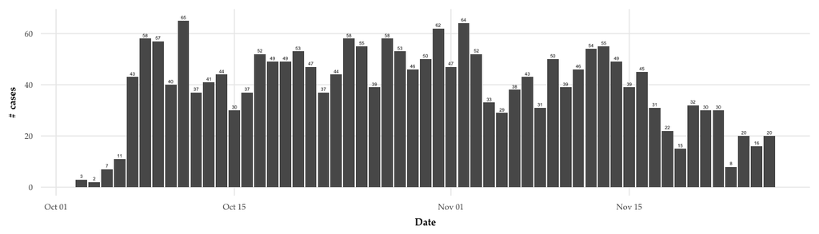

Tendance des cas de diarrhées aigues, 03 Oct 2016 - 26 Nov 2016 Grand’Anse (données partielles).

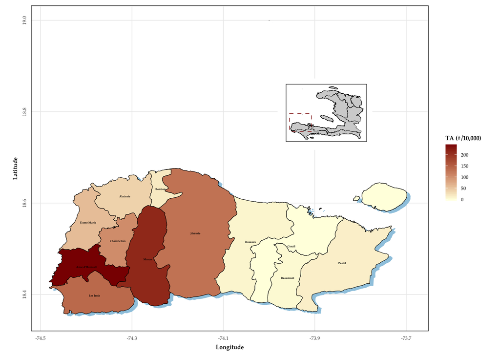

Répresentation du taux d’attaque des cas de diarrhées aigues par 10,000 personnes, 03 Oct 2016 - 26 Nov 2016 par commune, Grand’Anse

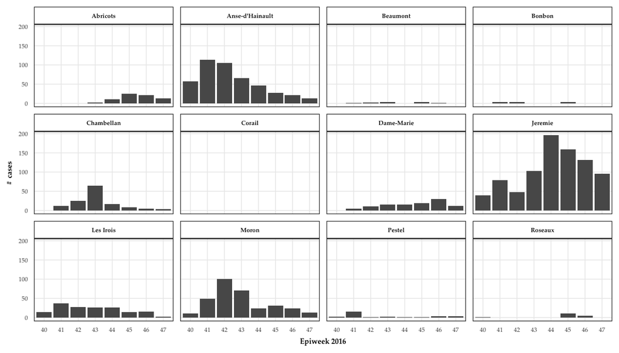

Tendance des cas de diarrhées aigues, 03 Oct 2016 - 26 Nov 2016 par commune, Grand’Anse

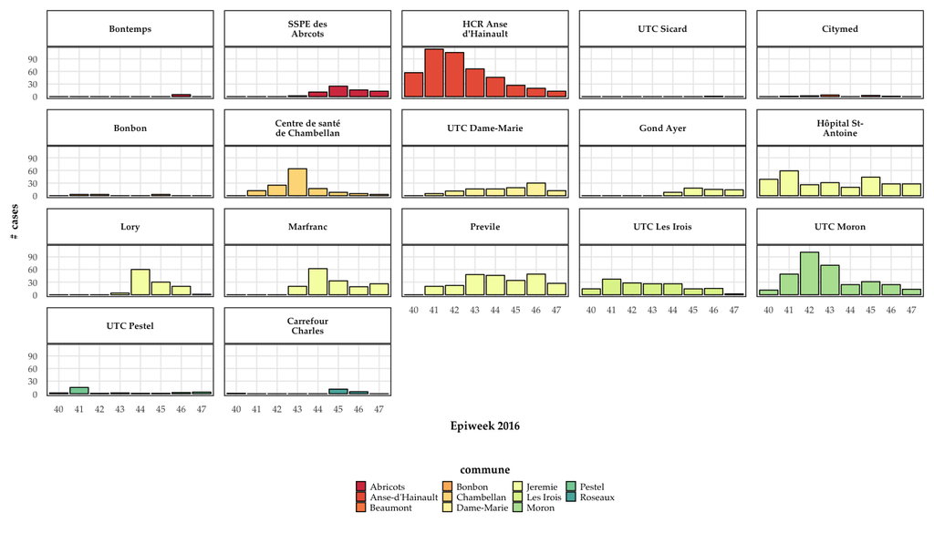

Tendance des cas de diarrhées aigues, 03 Oct 2016 - 26 Nov 2016 par CTC, Grand’Anse

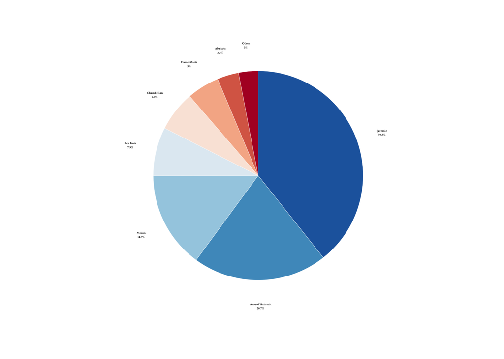

Répartition des cas de diarrhées aigues par commune, 03 Oct 2016 - 26 Nov 2016 Grand’Anse

Approximately 40% of acses have presented in Jérémie commune, 20% in Anse-d’Hainhault commune

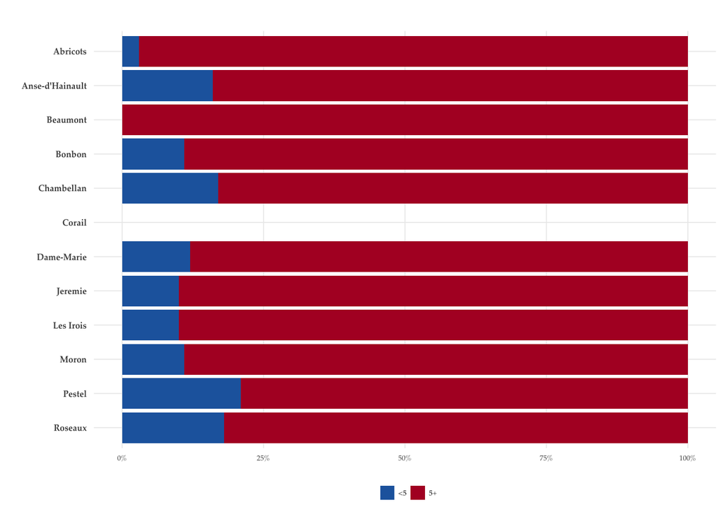

Répartition des cas de diarrhées aigues par tranche d’age, 03 Oct 2016 - 26 Nov 2016 par commune, Grand’Anse

## Additional sources of data

Two additional sources of information are currently unavailable but as they become available in the course of the coming weeks, they should be analysed and incorporated into the regular information products and feed into regular surveillance discussions in DSGA:

### Line-listed data from health facilities

Owing to the difficulty in collecting daily data from each facility, only aggregated data are currently collected. However, this leads to a loss of much important granularity of the data, e.g. prevenance, sex, treatment protocol and outcome, etc. This information is collected at the facilities and recorded in paper registers. The Centers for Disease Control and Prevention (CDC) are supporting MSPP and Medécins du Monde (MDM - the NGO supporting CTCs/UTCs in DSGA) in digitizing this information as line-lists. PAHO are providing some support to this process by photographing the registers during field visits, and providing these photos to MSPP/CDC for data entry. These data should be particularly used to identify demographic and geographic risk factors for suspected cholera transmission.

### Mobile clinics

On 22nd November 2016, mobile clinics were scheduled to restart their activities having been interrupted by the hurricane and heavy rains which had greatly hampered access to outreach communities. PAHO were asked to review the proposed list of conditions under surveillance and database structure in preparation for resumption of activities. Once these data are collected and centralised in the database, they will be a vital source of information about conditions of epidemic potential, particularly in more inaccessible communities.

# Field investigations

One of the roles of the PAHO field epidemiology team is to participate in regular field investigations. During my deployment, we participated in 4 investigations, including alerts of clusters of community cases and deaths, reports of institutional deaths, and to participate in routine assessments of CTCs. These are useful activities for a variety of reasons: - strengthening the relationship between PAHO and MSPP - MSPP tend to rely on the availability of vehicles belongin to partner organisations in order to make the field visits. - multidisciplinary visits for rationalising resources - prevents repeated trips to same locations and added burden to staff at CTCs - collecting and comparing data in registers with what is reported

# Recommendations

- Continue to support MSPP in field epidemiological investigations, but under more clearly defined SOPs.
- Continue to support weekly surveillance activities through data compilation, analysis, reporting and coordination.
- In the longer term, there is a need to transform the cholera surveillance system as the system currently in place is not fit for purpose. An improvement would be to ensure that:
  - the system is community based
  - information is collected at the individual level (i.e. line list to capture essential variables for analysis)
  - the data entry, compilation, analysis and reporting are streamlined, ideally making use of the WHO-led Early Warning Alert and Response System (EWARS) which is designed for such a context
- 2-level sensitivity analysis (Gignoux et al. 2015; Braeye et al. 2016)
  - from community to CTC
  - from CTC to central level
  - develop methodology for this
- document possible weaknesses in surveillance system through capture-recapture study to estimate sensitivity at 2 levels.
- It is also very important to not only focus on cholera response post Hurricane Matthew, as there are multiple other diseases and conditions of great importance in the département. Some important outstanding questions include:
  - what has been the impact on primary health care service delivery (e.g. Basic Emergency Obstetric Care)?
  - malaria surveillance
    - DSGA is considered one of the areas of greatest malaria incidence in Haiti. Has there been an impact on malaria incidence and access to treatment?
  - food security/malnutrition surveillance is an important consideration
    - Hurricane Matthew destroyed a large proportion of the crops, livestock, etc in the département, and a potentially serious impact on food security and concommitant impact on acute malnutrition should be anticipated. In this case, it may be prudent to establish some form of community-based malnutrition surveillance to early-detect deteriorations in the nutritional status of the population, particularly among children aged under 5. (Ref - Caleo, (G. M. Caleo et al. 2012; Polonsky et al. 2013), etc)

# Annexes

- protocol for investigation

# References

Braeye, Toon, Jan Verheagen, Annick Mignon, Wim Flipse, Denis Pierard, Kris Huygen, Carole Schirvel, and Niel Hens. 2016. “Capture-recapture estimators in epidemiology with applications to pertussis and pneumococcal invasive disease surveillance.” *PLoS ONE* 11 (8): 1–20.

Caleo, Grazia M, Aly Penda Sy, Serge Balandine, Jonathan Polonsky, Pedro Pablo Palma, Rebecca Freeman Grais, and Francesco Checchi. 2012. “Sentinel site community surveillance of mortality and nutritional status in southwestern Central African Republic, 2010.” *Population Health Metrics* 10 (1). Population Health Metrics: 18.

Gignoux, Etienne, Rachel Idowu, Luke Bawo, Lindis Hurum, Armand Sprecher, Mathieu Bastard, and Klaudia Porten. 2015. “Use of Capture–Recapture to Estimate Underreporting of Ebola Virus Disease, Montserrado County, Liberia.” *Emerging Infectious Diseases* 21 (12): 2265–7.

Polonsky, Jonathan, Francisco Luquero, Gwenola Francois, Caroline Rousseau, Grazia Caleo, Iza Ciglenecki, Clara Delacre, et al. 2013. “Public Health Surveillance After the 2010 Haiti Earthquake : the Experience of Médecins Sans Frontières.” *PLoS Currents* 5 (January): 1–19.

[^1]: [The R Project for Statistical Computing](https://www.r-project.org/)